# Using methylation to infer exposure patterns

Cancer Genetic Epidemiology course 2026

Author

Affiliation

Jose A. Seoane - joseaseoane@vhio.net

[Cancer Computational biology lab - VHIO](https://cancercompbiolab.github.io)

In this document we will explore a vignette on how to use the methodology explained in the course. We will use R and a set of packages available in CRAN or Bioconductor. You can reproduce the analysis with the code attached and analyze your favorite exposure.

# 1 Developing the exposure signature

The first step to develop the exposure signature is to identify the exposure or trait you want to analyse. For doing that, you will need the CpGs associated with the exposure, and the effect size from the EWAS. You can retrieve directly from the EWAS paper , but also you can explore several traits using on-line databases such as the EWAS Catalog from the University of Bristol.

## 1.1 Downloading the EWAS catalog

```r
library(downloader)
url_data = "https://www.ewascatalog.org/static//docs/ewascatalog-results.txt.gz"
dest_file = "EWAScatalog-results.txt.gz"
url_metadata = "https://www.ewascatalog.org/static//docs/ewascatalog-studies.txt.gz"
dest_file_meta = "ewascatalog-studies.txt.gz"


#download(url_data, dest_file, mode = "w", progress = TRUE)
#download(url_metadata, dest_file_meta, mode = "w", progress = TRUE)

ewas_data = read.table("ewascatalog-results.txt.gz",header = T,sep = "\t",stringsAsFactors = F)
ewas_metadata = read.table("ewascatalog-studies.txt.gz",header = T, sep="\t",stringsAsFactors = F,quote = '"')

arsenic_exposure_studies = ewas_metadata$StudyID[which(ewas_metadata$Exposure=="Arsenic exposure")]

ewas_data[which(ewas_data$StudyID == arsenic_exposure_studies[3]),c("CpG","Gene","Beta","P","StudyID")]
```

|  | CpG | Gene | Beta | P | StudyID |
| --- | --- | --- | --- | --- | --- |
| 392713 | cg00044289 | POP5 | 0.0068 | 9.4e-05 | 29982128_Battram-T_arsenic_exposure_ewas_catalog_re-analysis_of_geo_data__geo_accession_id_is_gse109914 |
| 392714 | cg00080423 | - | -0.0157 | 4.7e-05 | 29982128_Battram-T_arsenic_exposure_ewas_catalog_re-analysis_of_geo_data__geo_accession_id_is_gse109914 |
| 392715 | cg00118684 | RNMT;C18orf19 | 0.0105 | 8.7e-05 | 29982128_Battram-T_arsenic_exposure_ewas_catalog_re-analysis_of_geo_data__geo_accession_id_is_gse109914 |
| 392716 | cg00160914 | DDX20;C1orf183 | -0.0319 | 9.3e-05 | 29982128_Battram-T_arsenic_exposure_ewas_catalog_re-analysis_of_geo_data__geo_accession_id_is_gse109914 |
| 392717 | cg00213281 | KIF5C;MIR1978 | -0.0270 | 2.5e-05 | 29982128_Battram-T_arsenic_exposure_ewas_catalog_re-analysis_of_geo_data__geo_accession_id_is_gse109914 |
| 392718 | cg00224312 | PAN2 | 0.0055 | 4.6e-05 | 29982128_Battram-T_arsenic_exposure_ewas_catalog_re-analysis_of_geo_data__geo_accession_id_is_gse109914 |
| 392719 | cg00234046 | CDH23 | 0.0411 | 2.3e-05 | 29982128_Battram-T_arsenic_exposure_ewas_catalog_re-analysis_of_geo_data__geo_accession_id_is_gse109914 |
| 392720 | cg00293381 | ACADS | 0.0202 | 2.2e-05 | 29982128_Battram-T_arsenic_exposure_ewas_catalog_re-analysis_of_geo_data__geo_accession_id_is_gse109914 |
| 392721 | cg00326231 | CLTCL1 | 0.0126 | 2.5e-05 | 29982128_Battram-T_arsenic_exposure_ewas_catalog_re-analysis_of_geo_data__geo_accession_id_is_gse109914 |
| 392722 | cg00409844 | OCLN | 0.0221 | 5.7e-05 | 29982128_Battram-T_arsenic_exposure_ewas_catalog_re-analysis_of_geo_data__geo_accession_id_is_gse109914 |

[output cut: 360 more lines]

Lets define a signature from the literature, using a refined smoking signature (https://pmc.ncbi.nlm.nih.gov/articles/PMC6861351/),and a PM2.5 from EWAS of pollution (https://pmc.ncbi.nlm.nih.gov/articles/PMC6754789/). We have already available the signatures in the file Pheno_cge.csv

Here is the smoking signature

```r
Pheno = read.csv("Pheno_cge.csv", header=TRUE)
Pheno[which(Pheno$Trait=="smoking_sm13"),c("CpG", "Beta", "Trait")]
```

|  | CpG | Beta | Trait |
| --- | --- | --- | --- |
| 2890 | cg05575921 | -17.443 | smoking_sm13 |
| 2891 | cg13039251 | 9.241 | smoking_sm13 |
| 2892 | cg03636183 | -13.909 | smoking_sm13 |
| 2893 | cg12803068 | 6.479 | smoking_sm13 |
| 2894 | cg22132788 | 9.800 | smoking_sm13 |
| 2895 | cg06126421 | -9.415 | smoking_sm13 |
| 2896 | cg21566642 | -20.218 | smoking_sm13 |
| 2897 | cg15693572 | 4.189 | smoking_sm13 |
| 2898 | cg05951221 | -13.816 | smoking_sm13 |
| 2899 | cg12876356 | -4.741 | smoking_sm13 |

[output cut: 1 more lines]

And here the PM2.5 signature

```r
Pheno[which(Pheno$Trait=="pm2_5"),c("CpG", "Beta", "Trait")]
```

|  | CpG | Beta | Trait |
| --- | --- | --- | --- |
| 6746 | cg09731694 | -0.00052 | pm2_5 |
| 6747 | cg01948201 | -0.00064 | pm2_5 |
| 6748 | cg07316313 | -0.00067 | pm2_5 |
| 6749 | cg24988255 | -0.00077 | pm2_5 |
| 6750 | cg18580296 | -0.00030 | pm2_5 |
| 6751 | cg15201877 | -0.00065 | pm2_5 |
| 6752 | cg15232798 | -0.00047 | pm2_5 |
| 6753 | cg22453435 | 0.00067 | pm2_5 |
| 6754 | cg21632975 | -0.00070 | pm2_5 |
| 6755 | cg02341815 | -0.00038 | pm2_5 |

## 1.2 Calculating the signature

$$\begin{equation}
MethSign_{Trait_A} = \sum_{i=1}^m \beta_i DNAm_{CpG_i}
\end{equation}$$
which is literally a matrix product of the matrix of methylation beta values from the sample and the matrix of the effect sizes (in this case is a vector), and in R is implemented with the operator %*%.

```r
calcMRS = function(mat,Traits,trait){
  cpgs = Traits$CpG[which(Traits$Trait==trait)]
  bets = Traits$Beta[which(Traits$Trait==trait)]

  xx=data.frame(beta=bets,row.names = cpgs)


  return(t(mat[rownames(xx),]) %*% as.matrix(xx))
}
```

# 2 Validation of the signature

In order to see if this is reflecting the real exposure, we can validate the signatures in dataset where we have the exposure.

## 2.1 PM2.5 dataset

For example, in the dataset from GEO GSE289816 (https://www.ncbi.nlm.nih.gov/geo/query/acc.cgi?acc=GSE289816) we have methylation data from blood student of The University of Pirrsburg, which a median PM2.5 exposure of 12.1 ug/m3 and from students from the University of British Columnbia, with a median exposure of 5.1ug/m3. We will compare the methylation signature of PM2.5 with these two groups.

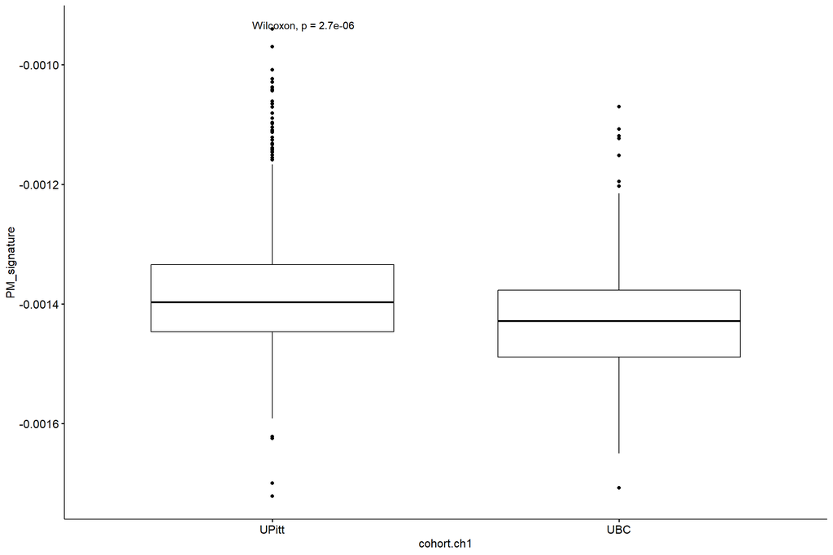

```r
met_mat_PM  <- readRDS("GSE289816_CGE.RDS")
pheno_pm = read.table("GSE289816_clinic_patient.csv",header = T,sep = ",")



pm_signature = calcMRS(met_mat_PM,Pheno,"pm2_5")
pheno_pm$PM_signature = pm_signature[,"beta"]

library(ggpubr)
ggboxplot(pheno_pm,x = "cohort.ch1",y="PM_signature" )+stat_compare_means()
```

## 2.2 Smoking dataset

Similarly, in the dataset GSE50660 (https://www.ncbi.nlm.nih.gov/geo/query/acc.cgi?acc=GSE50660 ), available from the publication (https://pmc.ncbi.nlm.nih.gov/articles/PMC4623553/), we have a 465 samples database with methylation and smoking status (Current, former or never smoker). We will compare the smoking signature agaisnt these tree groups.

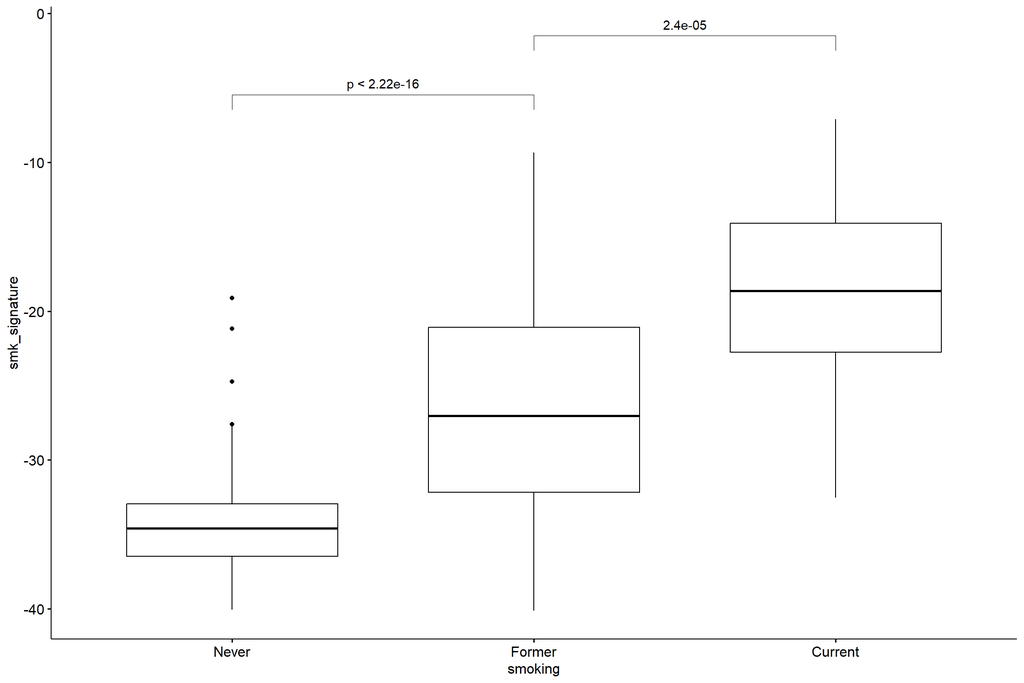

```r
met_mat_smk  <- readRDS("GSE50660_CGE.RDS")

pheno_smk = read.table("pData_GSE50660.csv",header = T,sep = ",")



smk_signature = calcMRS(met_mat_smk,Pheno,"smoking_sm13")
pheno_smk$smk_signature = smk_signature[,"beta"]


ggboxplot(pheno_smk,x = "smoking",y="smk_signature" )+
  stat_compare_means(comparisons = list(c("0","1"),c("1","2")))+
  scale_x_discrete(labels=c("0"="Never",
                            "1"="Former",
                            "2"="Current"))
```

# 3 Association of the signatures with early onset

## 3.1 Downloading TCGA data

TCGA data can we downloaded using this code. however, in order to facilitate the demo, we will use an already preprocessed methylation file from TCGA COAD the CpGs that we need (TCGA_COAD_Age_adj_cge.rds).

```r
# library(TCGAbiolinks)
# query <- GDCquery(project = "TCGA-COAD",   # "TCGA-READ"
#                   data.category = "Clinical",
#                   data.type = "Clinical Supplement")
# GDCdownload(query)
# clinical.BCRtab.all <- GDCprepare(query)
# clinic <- as.data.frame(clinical.BCRtab.all$clinical_patient_coad)
# #write.csv(clinic, "COAD_clinic.csv", row.names = F)
#
#
# library(TCGAbiolinks)
#
# query_met <- GDCquery(
#   project = "TCGA-COAD",  # "TCGA-READ"
#   data.category = "DNA Methylation",
#   data.type = "Methylation Beta Value",
#   platform = "Illumina Human Methylation 450")
#
#
# GDCdownload(query_met)
# met <- GDCprepare(query_met, summarizedExperiment=T)
#saveRDS(met,"TCGA_met_COAD.rds")
met_mat_M  <- readRDS("TCGA_COAD_Age_adj_cge.rds")
met_mat_M[1:10,1:5]
```

```
           TCGA-F4-6805 TCGA-CM-6678 TCGA-A6-A5ZU TCGA-AZ-6603 TCGA-A6-2675
cg09731694    0.5103709   0.55839170    0.2499371   0.61967749   0.51712610
cg01948201    0.2263465   0.19056122    0.1514530   0.13806301   0.13850533
cg07316313    0.6588662   0.58099409    0.6233039   0.63319656   0.69505937
cg24988255    0.1641545   0.13151429    0.6749453   0.14202924   0.12605821
cg18580296    0.1924265   0.44666843    0.1788905   0.32097888   0.17867484
cg15201877    0.3751336   0.51817041    0.4110630   0.27016509   0.50712833
cg15232798    0.1058566   0.10098877    0.1030263   0.06781080   0.09852151
cg22453435    0.1065481   0.08289081    0.1099772   0.06482815   0.07785326
cg21632975    0.5339230   0.35019361    0.4068206   0.33771990   0.39740167
cg02341815    0.4363375   0.55181991    0.5896018   0.62509204   0.51302460
```

Note that the values are Betas (0, non methylated < Beta < 1, methylated).

```r
clinic <- read.csv("Clinic_Coad.csv", header=T)
clinic$EOCRC = as.factor(ifelse(clinic$age < 50 , 1,
                                ifelse(clinic$age >=70, 0, NA)))
clinic <- clinic[complete.cases(clinic$EOCRC), ]
met_mat_M <- met_mat_M[, colnames(met_mat_M) %in% clinic$ID]
```

## 3.2 Calculate the signature

```r
sign_pm25 = calcMRS(met_mat_M,Pheno,"pm2_5")
sign_smoking = calcMRS(met_mat_M,Pheno,"smoking_sm13")

clinic$sign_pm25 = sign_pm25[match(clinic$ID,rownames(sign_pm25)),1]
clinic$sign_smoking = sign_smoking[match(clinic$ID,rownames(sign_smoking)),1]
```

## 3.3 Correlation of smoking with early onset

Let see how the exposome signatures of PM2.5 and smoking correlate with early onset.

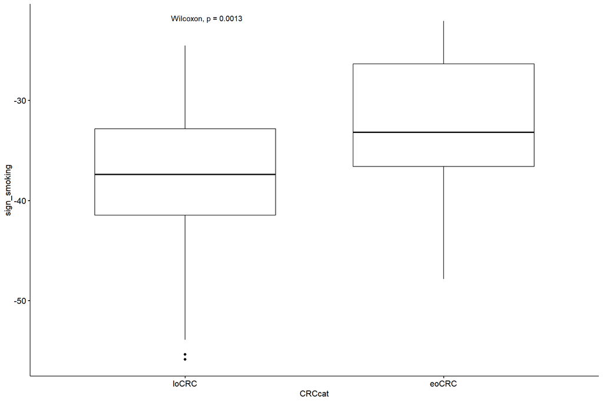

```r
library(ggpubr)
ggboxplot(clinic,x = "CRCcat",y="sign_smoking", )+stat_compare_means()
```

Smoking is higher in the early onset samples.

## 3.4 Correlation of pm2.5 with early onset

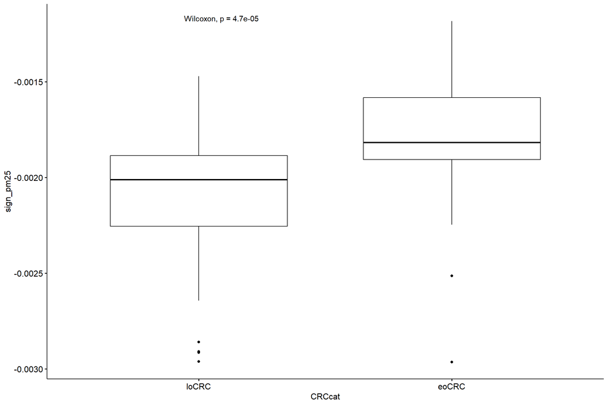

```r
ggboxplot(clinic,x = "CRCcat",y="sign_pm25" )+stat_compare_means()
```

Small particle matter is also higher in early-onset.

Further details of the data processing and methodology can be found in our group github

https://github.com/CancerCompBioLab/EOCRCexposome/

And in the preprint

https://www.researchsquare.com/article/rs-4528579